# Audio Emotion Classifier by Theon

```python
# Packages
import os
import numpy as np
import pandas as pd
import torch
import librosa
import numpy as np
from torch.utils.data import Dataset
from torch.utils.data import DataLoader
import torch.nn as nn
import torch.nn.functional as F
import random

random.seed(1)
```

## RAVDESS

- Ryerson Audio-Visual Database of Emotional Speech and Song (RAVDESS)

1440 files in total. The RAVDESS contains 24 professional actors(neutral North American accent). Speech emotions include calm, happy, sad, angry, fearful, surprise, and disgust expressions. Each expression is produced at two levels of emotional intensity (normal, strong), with an additional neutral expression.

*The following datasets are processed with a similar pipeline.*

```python
RAVDESS = './data/RAVDESS/'
ravdess_directory_list = os.listdir(RAVDESS)
type = []
actor_list = []
path_list = []
gender_list = []
emotion_list = []

code_to_emotion = {
    '03' : 'happy',
    '01' : 'neutral',
    '04' : 'sad',
    '05' : 'angry',
    '06' : 'fear',
    '07' : 'disgust',
}

# Building standard dataframe
for directory in ravdess_directory_list:
    actor_files = os.listdir(os.path.join(RAVDESS, directory))
    for audio_file in actor_files:
        part = audio_file.split('.')[0]
        code = part.split('-')[2]
        if code in code_to_emotion:
            gender_code = int(part.split('-')[6])
            type.append('RAVDESS')  # Dataset name
            actor_list.append(directory)  # Actor
            path_list.append(f"{RAVDESS}{directory}/{audio_file}")  # File path
            gender_list.append('female' if gender_code & 1 == 0 else 'male')  # Gender
            emotion_list.append(code_to_emotion[code])  # Emotion


ravdess = pd.concat([
    pd.DataFrame(type, columns=['type']),
    pd.DataFrame(actor_list, columns=['actor']),
    pd.DataFrame(path_list, columns=['path']),
    pd.DataFrame(gender_list, columns=['sex']),
    pd.DataFrame(emotion_list, columns=['emotion'])
], axis=1)

ravdess.head()
```

|  | type | actor | path | sex | emotion |
| --- | --- | --- | --- | --- | --- |
| 0 | RAVDESS | Actor_01 | ./data/RAVDESS/Actor_01/03-01-01-01-01-01-01.wav | male | neutral |
| 1 | RAVDESS | Actor_01 | ./data/RAVDESS/Actor_01/03-01-01-01-01-02-01.wav | male | neutral |
| 2 | RAVDESS | Actor_01 | ./data/RAVDESS/Actor_01/03-01-01-01-02-01-01.wav | male | neutral |
| 3 | RAVDESS | Actor_01 | ./data/RAVDESS/Actor_01/03-01-01-01-02-02-01.wav | male | neutral |
| 4 | RAVDESS | Actor_01 | ./data/RAVDESS/Actor_01/03-01-03-01-01-01-01.wav | male | happy |

```python
# Map emotion names to numeric labels
RAVDESS_EMOTION_MAP = {
    'angry': 0,
    'disgust': 1,
    'fear': 2,
    'happy': 3,
    'neutral': 4,
    'sad': 5
}

ravdess = ravdess[ravdess["emotion"].isin(RAVDESS_EMOTION_MAP.keys())]
ravdess["label"] = ravdess["emotion"].map(RAVDESS_EMOTION_MAP)

# Rename columns
ravdess = ravdess.rename(columns={"path": "file"})

print(ravdess.head())
print(ravdess["label"].value_counts())
print(ravdess["sex"].value_counts())
```

```
      type     actor                                              file   sex  \
0  RAVDESS  Actor_01  ./data/RAVDESS/Actor_01/03-01-01-01-01-01-01.wav  male
1  RAVDESS  Actor_01  ./data/RAVDESS/Actor_01/03-01-01-01-01-02-01.wav  male
2  RAVDESS  Actor_01  ./data/RAVDESS/Actor_01/03-01-01-01-02-01-01.wav  male
3  RAVDESS  Actor_01  ./data/RAVDESS/Actor_01/03-01-01-01-02-02-01.wav  male
4  RAVDESS  Actor_01  ./data/RAVDESS/Actor_01/03-01-03-01-01-01-01.wav  male

   emotion  label
0  neutral      4
1  neutral      4
2  neutral      4
3  neutral      4
4    happy      3
label
3    192
5    192
0    192
2    192
1    192
4     96
Name: count, dtype: int64
sex
male      528
female    528
Name: count, dtype: int64
```

## Crema-D

- Crowd Sourced Emotional Multimodal Actors Dataset (CREMA-D)

A data set of 7442 original clips from 91 actors. Actors spoke from a selection of 12 sentences. The sentences were presented using one of six different emotions (Anger, Disgust, Fear, Happy, Neutral, and Sad) and four different emotion levels (Low, Medium, High, and Unspecified).

```python
# All female actor id
female_id_set = {
    '1002','1003','1004','1006','1007','1008','1009','1010','1012','1013',
    '1018','1020','1021','1024','1025','1028','1029','1030','1037','1043',
    '1046','1047','1049','1052','1053','1054','1055','1056','1058','1060',
    '1061','1063','1072','1073','1074','1075','1076','1078','1079','1082',
    '1084','1089','1091'
}
```

```python
EMOTION_MAP = {
    'ANG': 0,
    'DIS': 1,
    'FEA': 2,
    'HAP': 3,
    'NEU': 4,
    'SAD': 5
}

audio_dir = "./data/AudioWAV/"

files = [f for f in os.listdir(audio_dir) if f.endswith(".wav")]
data = []

for f in files:
    parts = f.split("_")
    actor_id = parts[0]
    emotion = parts[2]
    type = 'Crema-D'  # Dataset name

    # Mark gender
    if actor_id not in female_id_set:
        sex = 'male'
    else:
        sex = 'female'

    if emotion not in EMOTION_MAP:
        continue

    emotion_label = EMOTION_MAP[emotion]

    data.append({
        "type": type,
        "file": os.path.join(audio_dir, f),
        "actor": actor_id,
        "sex": sex,
        "emotion": emotion,
        "label": emotion_label
    })

df = pd.DataFrame(data)
print(df.head())
print(df["label"].value_counts())
print(df["sex"].value_counts())
```

```
      type                                 file actor   sex emotion  label
0  Crema-D  ./data/AudioWAV/1001_DFA_ANG_XX.wav  1001  male     ANG      0
1  Crema-D  ./data/AudioWAV/1001_DFA_DIS_XX.wav  1001  male     DIS      1
2  Crema-D  ./data/AudioWAV/1001_DFA_FEA_XX.wav  1001  male     FEA      2
3  Crema-D  ./data/AudioWAV/1001_DFA_HAP_XX.wav  1001  male     HAP      3
4  Crema-D  ./data/AudioWAV/1001_DFA_NEU_XX.wav  1001  male     NEU      4
label
0    1271
1    1271
2    1271
3    1271
5    1271
4    1087
Name: count, dtype: int64
sex
male      3930
female    3512
Name: count, dtype: int64
```

```python
# Downsample Crema-D to balance training data
target_per_class = {
    0: 0,  # angry
    1: 900,  # disgust
    2: 700,  # fear
    3: 450,  # happy
    4: 0,  # neutral
    5: 300   # sad
}

balanced_data = []

for label in sorted(df["label"].unique()):

    df_label = df[df["label"] == label]

    target_total = target_per_class[label]
    target_gender = target_total // 5

    df_male = df_label[df_label["sex"] == "male"]
    df_female = df_label[df_label["sex"] == "female"]

    if len(df_male) < target_gender or len(df_female) < target_gender:
        print(f"Warning: Not enough samples for label {label}")
        continue

    # Also balance male and female
    df_male_sampled = df_male.sample(n=target_gender*3, random_state=42)
    df_female_sampled = df_female.sample(n=target_gender*2, random_state=42)

    balanced_data.append(df_male_sampled)
    balanced_data.append(df_female_sampled)

df = pd.concat(balanced_data).reset_index(drop=True)

# Check
print("\nAfter balancing:")
print(df.head())
print(df["label"].value_counts())
print(df["sex"].value_counts())
```

```
After balancing:
      type                                 file actor   sex emotion  label
0  Crema-D  ./data/AudioWAV/1048_TSI_DIS_XX.wav  1048  male     DIS      1
1  Crema-D  ./data/AudioWAV/1027_ITH_DIS_XX.wav  1027  male     DIS      1
2  Crema-D  ./data/AudioWAV/1067_ITH_DIS_XX.wav  1067  male     DIS      1
3  Crema-D  ./data/AudioWAV/1087_TSI_DIS_XX.wav  1087  male     DIS      1
4  Crema-D  ./data/AudioWAV/1039_TAI_DIS_XX.wav  1039  male     DIS      1
label
1    900
2    700
3    450
5    300
Name: count, dtype: int64
sex
male      1410
female     940
Name: count, dtype: int64
```

## Tess

2800 audio files in total. A set of 200 target words was spoken in the carrier phrase “Say the word …” by two actresses. Recordings were made of the set portraying each of seven emotions (anger, disgust, fear, happiness, pleasant surprise, sadness, and neutral).

```python
TESS = './data/TESS/'
tess_dir_list = os.listdir(TESS)
type = []
actor_list = []
path_list = []
gender_list = []
emotion_list = []

code_to_emotion = {
    'happy'   : 'happy',
    'neutral' : 'neutral',
    'sad'     : 'sad',
    'Sad'     : 'sad',
    'angry'   : 'angry',
    'fear'    : 'fear',
    'disgust' : 'disgust',
}

# Building standard dataframe
for directory in tess_dir_list:
    audio_files = os.listdir(os.path.join(TESS, directory))
    for audio_file in audio_files:
        part = audio_file.split('.')[0]
        actor = directory.split('_')[0]
        code = part.split('_')[2]
        if code in code_to_emotion:
            type.append('TESS')
            actor_list.append(actor)
            path_list.append(f"{TESS}{directory}/{audio_file}")
            gender_list.append('female') # female only dataset
            emotion_list.append(code_to_emotion[code])

tess = pd.concat([
    pd.DataFrame(type, columns=['type']),
    pd.DataFrame(actor_list, columns=['actor']),
    pd.DataFrame(path_list, columns=['path']),
    pd.DataFrame(gender_list, columns=['sex']),
    pd.DataFrame(emotion_list, columns=['emotion'])
], axis=1)

tess.head()
```

|  | type | actor | path | sex | emotion |
| --- | --- | --- | --- | --- | --- |
| 0 | TESS | OAF | ./data/TESS/OAF_angry/OAF_back_angry.wav | female | angry |
| 1 | TESS | OAF | ./data/TESS/OAF_angry/OAF_bar_angry.wav | female | angry |
| 2 | TESS | OAF | ./data/TESS/OAF_angry/OAF_base_angry.wav | female | angry |
| 3 | TESS | OAF | ./data/TESS/OAF_angry/OAF_bath_angry.wav | female | angry |
| 4 | TESS | OAF | ./data/TESS/OAF_angry/OAF_bean_angry.wav | female | angry |

```python
# Map emotion names to numeric labels
TESS_EMOTION_MAP = {
    'angry': 0,
    'disgust': 1,
    'fear': 2,
    'happy': 3,
    'neutral': 4,
    'sad': 5
}

tess = tess[tess["emotion"].isin(TESS_EMOTION_MAP.keys())]

tess["label"] = tess["emotion"].map(TESS_EMOTION_MAP)

# Rename columns
tess = tess.rename(columns={"path": "file"})

# Balanced sampling: emotion + actor
samples_per_emotion = 1200 // len(TESS_EMOTION_MAP)
actors = tess["actor"].unique()
num_actors = len(actors)

samples_per_actor = samples_per_emotion // num_actors

balanced_groups = []

for (emotion, actor), group in tess.groupby(["emotion", "actor"]):

    # in case some groups are smaller
    n = min(len(group), samples_per_actor)

    balanced_groups.append(
        group.sample(n=n, random_state=42)
    )

tess = pd.concat(balanced_groups).reset_index(drop=True)

print(tess.head())
print(tess["label"].value_counts())
print(tess["sex"].value_counts())
print(tess["actor"].value_counts())
```

```
   type actor                                       file     sex emotion  \
0  TESS   OAF   ./data/TESS/OAF_angry/OAF_luck_angry.wav  female   angry
1  TESS   OAF  ./data/TESS/OAF_angry/OAF_cause_angry.wav  female   angry
2  TESS   OAF   ./data/TESS/OAF_angry/OAF_dime_angry.wav  female   angry
3  TESS   OAF   ./data/TESS/OAF_angry/OAF_soup_angry.wav  female   angry
4  TESS   OAF    ./data/TESS/OAF_angry/OAF_rag_angry.wav  female   angry

   label
0      0
1      0
2      0
3      0
4      0
label
0    200
1    200
2    200
3    200
4    200
5    200
Name: count, dtype: int64
sex
female    1200
Name: count, dtype: int64
actor
OAF    600
YAF    600
Name: count, dtype: int64
```

## EmoDB

A German emotional dataset. Ten professional speakers participated in data recording, and the database contains a total of 535 utterances.

```python
EMODB = './data/EmoDB/'
emodb_directory_list = os.listdir(EMODB)
type = []
actor_list = []
path_list = []
gender_list = []
emotion_list = []

code_to_emotion = {
    'W' : 'angry',
    'E' : 'disgust',
    'A' : 'fear',
    'F' : 'happy',
    'T' : 'sad',
    'N' : 'neutral'
}

female_id_set = {
    '08', '09', '13', '14', '16'
}  # Female actor id

# Building standard dataframe
for audio_file in emodb_directory_list:
    part = audio_file.split('.')[0]
    code = part[-2]
    if code in code_to_emotion:
        type.append('EmoDB')
        actor_list.append(part[0:2])
        path_list.append(f"{EMODB}{audio_file}")
        gender_list.append('female' if part[0:2] in female_id_set else 'male')
        emotion_list.append(code_to_emotion[code])

emodb = pd.concat([
    pd.DataFrame(type, columns=['type']),
    pd.DataFrame(actor_list, columns=['actor']),
    pd.DataFrame(path_list, columns=['path']),
    pd.DataFrame(gender_list, columns=['sex']),
    pd.DataFrame(emotion_list, columns=['emotion']),
], axis=1)

emodb.head()
```

|  | type | actor | path | sex | emotion |
| --- | --- | --- | --- | --- | --- |
| 0 | EmoDB | 03 | ./data/EmoDB/03a01Fa.wav | male | happy |
| 1 | EmoDB | 03 | ./data/EmoDB/03a01Nc.wav | male | neutral |
| 2 | EmoDB | 03 | ./data/EmoDB/03a01Wa.wav | male | angry |
| 3 | EmoDB | 03 | ./data/EmoDB/03a02Fc.wav | male | happy |
| 4 | EmoDB | 03 | ./data/EmoDB/03a02Nc.wav | male | neutral |

```python
# Map emotion names to numeric labels
EMODB_EMOTION_MAP = {
    'angry': 0,
    'disgust': 1,
    'fear': 2,
    'happy': 3,
    'neutral': 4,
    'sad': 5
}

emodb = emodb[emodb["emotion"].isin(EMODB_EMOTION_MAP.keys())]
emodb["label"] = emodb["emotion"].map(EMODB_EMOTION_MAP)

# Rename columns
emodb = emodb.rename(columns={"path": "file"})

print(emodb.head())
print(emodb["label"].value_counts())
print(emodb["sex"].value_counts())
```

```
    type actor                      file   sex  emotion  label
0  EmoDB    03  ./data/EmoDB/03a01Fa.wav  male    happy      3
1  EmoDB    03  ./data/EmoDB/03a01Nc.wav  male  neutral      4
2  EmoDB    03  ./data/EmoDB/03a01Wa.wav  male    angry      0
3  EmoDB    03  ./data/EmoDB/03a02Fc.wav  male    happy      3
4  EmoDB    03  ./data/EmoDB/03a02Nc.wav  male  neutral      4
label
0    127
4     79
3     71
2     69
5     62
1     46
Name: count, dtype: int64
sex
female    256
male      198
Name: count, dtype: int64
```

## ShEMO

A Persian emotional dataset. The database includes 3000 semi-natural utterances, covering speech samples of 87 native-Persian speakers for five basic emotions, including anger, fear, happiness, sadness, and surprise, as well as a neutral state

```python
ShEMO = './data/ShEMO/'
ShEMO_directory_list = os.listdir(ShEMO)
type = []
actor_list = []
path_list = []
gender_list = []
emotion_list = []

code_to_emotion = {
    'H' : 'happy',
    'N' : 'neutral',
    'S' : 'sad',
    'A' : 'angry',
    'F' : 'fear'
}

# Building standard dataframe
for audio_file in ShEMO_directory_list:
    sex = audio_file[0]
    actor = audio_file[0:3]
    code = audio_file[3]
    if code in code_to_emotion:
        type.append('ShEMO')
        actor_list.append(actor)
        path_list.append(f"{ShEMO}{audio_file}")
        gender_list.append('male' if sex == 'M' else 'female')
        emotion_list.append(code_to_emotion[code])

ShEMO = pd.concat([
    pd.DataFrame(type, columns=['type']),
    pd.DataFrame(actor_list, columns=['actor']),
    pd.DataFrame(path_list, columns=['path']),
    pd.DataFrame(gender_list, columns=['sex']),
    pd.DataFrame(emotion_list, columns=['emotion'])
], axis=1)

ShEMO.head()
```

|  | type | actor | path | sex | emotion |
| --- | --- | --- | --- | --- | --- |
| 0 | ShEMO | F01 | ./data/ShEMO/F01A01.wav | female | angry |
| 1 | ShEMO | F01 | ./data/ShEMO/F01A02.wav | female | angry |
| 2 | ShEMO | F01 | ./data/ShEMO/F01A03.wav | female | angry |
| 3 | ShEMO | F01 | ./data/ShEMO/F01A04.wav | female | angry |
| 4 | ShEMO | F01 | ./data/ShEMO/F01A05.wav | female | angry |

```python
# Map emotion names to numeric labels
ShEMO_EMOTION_MAP = {
    'angry': 0,
    'disgust': 1,
    'fear': 2,
    'happy': 3,
    'neutral': 4,
    'sad': 5
}

ShEMO = ShEMO[ShEMO["emotion"].isin(ShEMO_EMOTION_MAP.keys())]
ShEMO["label"] = ShEMO["emotion"].map(ShEMO_EMOTION_MAP)

# Rename columns
ShEMO = ShEMO.rename(columns={"path": "file"})

print(ShEMO.head())
print(ShEMO["label"].value_counts())
print(ShEMO["sex"].value_counts())
```

```
    type actor                     file     sex emotion  label
0  ShEMO   F01  ./data/ShEMO/F01A01.wav  female   angry      0
1  ShEMO   F01  ./data/ShEMO/F01A02.wav  female   angry      0
2  ShEMO   F01  ./data/ShEMO/F01A03.wav  female   angry      0
3  ShEMO   F01  ./data/ShEMO/F01A04.wav  female   angry      0
4  ShEMO   F01  ./data/ShEMO/F01A05.wav  female   angry      0
label
0    1059
4    1028
5     449
3     201
2      38
Name: count, dtype: int64
sex
male      1632
female    1143
Name: count, dtype: int64
```

## EMOVO

Italian Language Speech Emotion Recognition Dataset.

```python
EMOVO = './data/EMOVO/'
EMOVO_dir_list = os.listdir(EMOVO)
type = []
actor_list = []
path_list = []
gender_list = []
emotion_list = []

code_to_emotion = {
    'gio' : 'happy',
    'neu' : 'neutral',
    'tri' : 'sad',
    'rab' : 'angry',
    'pau' : 'fear',
    'dis' : 'disgust',
}

# Building standard dataframe
for directory in EMOVO_dir_list:
    audio_files = os.listdir(os.path.join(EMOVO, directory))
    for audio_file in audio_files:
        actor = audio_file.split('-')[1]
        code = audio_file.split('-')[0]
        if code in code_to_emotion:
            type.append('EMOVO')
            actor_list.append(actor)
            path_list.append(f"{EMOVO}{directory}/{audio_file}")
            gender_list.append('female' if directory[0] == 'f' else 'male')
            emotion_list.append(code_to_emotion[code])

EMOVO = pd.concat([
    pd.DataFrame(type, columns=['type']),
    pd.DataFrame(actor_list, columns=['actor']),
    pd.DataFrame(path_list, columns=['path']),
    pd.DataFrame(gender_list, columns=['sex']),
    pd.DataFrame(emotion_list, columns=['emotion'])
], axis=1)

EMOVO.head()
```

|  | type | actor | path | sex | emotion |
| --- | --- | --- | --- | --- | --- |
| 0 | EMOVO | f1 | ./data/EMOVO/f1/dis-f1-b1.wav | female | disgust |
| 1 | EMOVO | f1 | ./data/EMOVO/f1/dis-f1-b2.wav | female | disgust |
| 2 | EMOVO | f1 | ./data/EMOVO/f1/dis-f1-b3.wav | female | disgust |
| 3 | EMOVO | f1 | ./data/EMOVO/f1/dis-f1-d1.wav | female | disgust |
| 4 | EMOVO | f1 | ./data/EMOVO/f1/dis-f1-d2.wav | female | disgust |

```python
# Map emotion names to numeric labels
EMOVO_EMOTION_MAP = {
    'angry': 0,
    'disgust': 1,
    'fear': 2,
    'happy': 3,
    'neutral': 4,
    'sad': 5
}

EMOVO = EMOVO[EMOVO["emotion"].isin(EMOVO_EMOTION_MAP.keys())]
EMOVO["label"] = EMOVO["emotion"].map(EMOVO_EMOTION_MAP)

# Rename columns
EMOVO = EMOVO.rename(columns={"path": "file"})

print(EMOVO.head())
print(EMOVO["label"].value_counts())
print(EMOVO["sex"].value_counts())
```

```
    type actor                           file     sex  emotion  label
0  EMOVO    f1  ./data/EMOVO/f1/dis-f1-b1.wav  female  disgust      1
1  EMOVO    f1  ./data/EMOVO/f1/dis-f1-b2.wav  female  disgust      1
2  EMOVO    f1  ./data/EMOVO/f1/dis-f1-b3.wav  female  disgust      1
3  EMOVO    f1  ./data/EMOVO/f1/dis-f1-d1.wav  female  disgust      1
4  EMOVO    f1  ./data/EMOVO/f1/dis-f1-d2.wav  female  disgust      1
label
1    84
3    84
4    84
2    84
0    84
5    84
Name: count, dtype: int64
sex
female    252
male      252
Name: count, dtype: int64
```

## RAVDESS Song

- Ryerson Audio-Visual Database of Emotional Speech and Song (RAVDESS)

Song version of RAVDESS. But note that there is no disgust in RAVDESS Song.

```python
RAVDESS_song = './data/RAV_song/'
RAVDESS_song_directory_list = os.listdir(RAVDESS_song)
type = []
actor_list = []
path_list = []
gender_list = []
emotion_list = []

code_to_emotion = {
    '03' : 'happy',
    '01' : 'neutral',
    '04' : 'sad',
    '05' : 'angry',
    '06' : 'fear',
    '07' : 'disgust',
}

# Building standard dataframe
for directory in RAVDESS_song_directory_list:
    actor_files = os.listdir(os.path.join(RAVDESS_song, directory))
    for audio_file in actor_files:
        part = audio_file.split('.')[0]
        code = part.split('-')[2]
        if code in code_to_emotion:
            gender_code = int(part.split('-')[6])
            type.append('RAV_song')
            actor_list.append(directory)
            path_list.append(f"{RAVDESS_song}{directory}/{audio_file}")
            gender_list.append('female' if gender_code & 1 == 0 else 'male')
            emotion_list.append(code_to_emotion[code])


RAVDESS_song = pd.concat([
    pd.DataFrame(type, columns=['type']),
    pd.DataFrame(actor_list, columns=['actor']),
    pd.DataFrame(path_list, columns=['path']),
    pd.DataFrame(gender_list, columns=['sex']),
    pd.DataFrame(emotion_list, columns=['emotion'])
], axis=1)

# RAVDESS_song = RAVDESS_song[RAVDESS_song["sex"] == 'female']
RAVDESS_song.head()
```

|  | type | actor | path | sex | emotion |
| --- | --- | --- | --- | --- | --- |
| 0 | RAV_song | Actor_01 | ./data/RAV_song/Actor_01/03-02-01-01-01-01-01.wav | male | neutral |
| 1 | RAV_song | Actor_01 | ./data/RAV_song/Actor_01/03-02-01-01-01-02-01.wav | male | neutral |
| 2 | RAV_song | Actor_01 | ./data/RAV_song/Actor_01/03-02-01-01-02-01-01.wav | male | neutral |
| 3 | RAV_song | Actor_01 | ./data/RAV_song/Actor_01/03-02-01-01-02-02-01.wav | male | neutral |
| 4 | RAV_song | Actor_01 | ./data/RAV_song/Actor_01/03-02-03-01-01-01-01.wav | male | happy |

```python
# Map emotion names to numeric labels
RAVDESS_song_EMOTION_MAP = {
    'angry': 0,
    'disgust': 1,
    'fear': 2,
    'happy': 3,
    'neutral': 4,
    'sad': 5
}

RAVDESS_song = RAVDESS_song[RAVDESS_song["emotion"].isin(RAVDESS_song_EMOTION_MAP.keys())]
RAVDESS_song["label"] = RAVDESS_song["emotion"].map(RAVDESS_song_EMOTION_MAP)

# Rename columns
RAVDESS_song = RAVDESS_song.rename(columns={"path": "file"})

print(RAVDESS_song.head())
print(RAVDESS_song["label"].value_counts())
print(RAVDESS_song["sex"].value_counts())
```

```
       type     actor                                               file  \
0  RAV_song  Actor_01  ./data/RAV_song/Actor_01/03-02-01-01-01-01-01.wav
1  RAV_song  Actor_01  ./data/RAV_song/Actor_01/03-02-01-01-01-02-01.wav
2  RAV_song  Actor_01  ./data/RAV_song/Actor_01/03-02-01-01-02-01-01.wav
3  RAV_song  Actor_01  ./data/RAV_song/Actor_01/03-02-01-01-02-02-01.wav
4  RAV_song  Actor_01  ./data/RAV_song/Actor_01/03-02-03-01-01-01-01.wav

    sex  emotion  label
0  male  neutral      4
1  male  neutral      4
2  male  neutral      4
3  male  neutral      4
4  male    happy      3
label
3    184
5    184
0    184
2    184
4     92
Name: count, dtype: int64
sex
male      432
female    396
Name: count, dtype: int64
```

## Friends (self collected [English] TV data)

Data collected from Friends, the TV show.

```python
# Mapping
EMOTION_MAP = {
    'ANG': 0,
    'DIS': 1,
    'FEA': 2,
    'HAP': 3,
    'NEU': 4,
    'SAD': 5
}

emotion_convert = {
    'angry': 'ANG',
    'disgust': 'DIS',
    'fear': 'FEA',
    'happy': 'HAP',
    'neutral': 'NEU',
    'sad': 'SAD'
}
```

```python
data_dir = "./data/reallife/wav/ENG"
rows = []

for filename in os.listdir(data_dir):

    if filename.endswith(".wav"):
        parts = filename.replace(".wav", "").split("_")

        actor_id = parts[0]  # Actor
        emotion_word = parts[1].lower()  # Emotion
        sex = parts[2].lower()  # Gender

        emotion_code = emotion_convert[emotion_word]  # Mapping
        label = EMOTION_MAP[emotion_code]

        rows.append({
            "file": os.path.join(data_dir, filename),
            "type": 'Friends',
            "actor": actor_id,
            "emotion": emotion_code,
            "label": label,
            "sex": sex
        })

friends = pd.DataFrame(rows)
print(friends.head())
```

```
                                                file     type     actor  \
0  ./data/reallife/wav/ENG\Chandler_angry_male_1.wav  Friends  Chandler
1  ./data/reallife/wav/ENG\Chandler_angry_male_10...  Friends  Chandler
2  ./data/reallife/wav/ENG\Chandler_angry_male_2.wav  Friends  Chandler
3  ./data/reallife/wav/ENG\Chandler_angry_male_3.wav  Friends  Chandler
4  ./data/reallife/wav/ENG\Chandler_angry_male_4.wav  Friends  Chandler

  emotion  label   sex
0     ANG      0  male
1     ANG      0  male
2     ANG      0  male
3     ANG      0  male
4     ANG      0  male
```

## iPartment (self collected [Chinese] TV data)

Data collected from iPartment, a famous Chinese TV show.

```python
data_dir = "./data/reallife/wav/CHI"
rows = []

for filename in os.listdir(data_dir):

    if filename.endswith(".wav"):
        parts = filename.replace(".wav", "").split("_")

        actor_id = parts[0]  # Actor
        emotion_word = parts[1].lower()  # Emotion
        sex = parts[2].lower()  # Gender

        emotion_code = emotion_convert[emotion_word]  # Mapping
        label = EMOTION_MAP[emotion_code]

        rows.append({
            "file": os.path.join(data_dir, filename),
            "type": 'iPartment',
            "actor": actor_id,
            "emotion": emotion_code,
            "label": label,
            "sex": sex
        })

ipartment = pd.DataFrame(rows)
print(ipartment.head())
```

```
                                              file       type actor emotion  \
0    ./data/reallife/wav/CHI\关谷神奇_angry_male_1.wav  iPartment  关谷神奇     ANG
1    ./data/reallife/wav/CHI\关谷神奇_angry_male_2.wav  iPartment  关谷神奇     ANG
2    ./data/reallife/wav/CHI\关谷神奇_angry_male_3.wav  iPartment  关谷神奇     ANG
3  ./data/reallife/wav/CHI\关谷神奇_disgust_male_1.wav  iPartment  关谷神奇     DIS
4     ./data/reallife/wav/CHI\关谷神奇_fear_male_1.wav  iPartment  关谷神奇     FEA

   label   sex
0      0  male
1      0  male
2      0  male
3      1  male
4      2  male
```

## Combine Datasets

```python
# Combine all datasets
combined_df = pd.concat([df, ravdess, tess, emodb, friends, ipartment, ShEMO, EMOVO, RAVDESS_song], ignore_index=True)
print('\nCheck label:\n')
print(combined_df["label"].value_counts())
print('\nCheck dataset type:\n')
print(combined_df["type"].value_counts())
print('\nCheck actors:\n')
print(combined_df["actor"].value_counts())
print('\nCheck sex:\n')
print(combined_df["sex"].value_counts())
```

```
Check label:

label
0    1990
4    1933
5    1613
2    1576
3    1539
1    1533
Name: count, dtype: int64

Check dataset type:

type
ShEMO        2775
Crema-D      2350
TESS         1200
RAVDESS      1056
RAV_song      828
iPartment     657
EMOVO         504
EmoDB         454
Friends       360
Name: count, dtype: int64

Check actors:

actor
OAF    600
YAF    600
M12    171
F21    141
F07    136
      ...
M33      3
M01      3
林婉瑜      3
M35      2
F08      1
Name: count, Length: 239, dtype: int64

Check sex:

sex
female    5207
male      4977
Name: count, dtype: int64
```

## Train-Val-Test Split

```python
from sklearn.model_selection import train_test_split

def split_df(df):
    train, temp = train_test_split(
        df,
        test_size=0.3,
        stratify=df["label"],
        random_state=42
    )

    val, test = train_test_split(
        temp,
        test_size=0.5,
        stratify=temp["label"],
        random_state=42
    )

    return train, val, test
```

```python
datasets = [df, ravdess, tess, emodb, friends, ipartment, ShEMO, EMOVO, RAVDESS_song]

train_list, val_list, test_list = [], [], []

for d in datasets:
    train_d, val_d, test_d = split_df(d)
    train_list.append(train_d)
    val_list.append(val_d)
    test_list.append(test_d)

train_df = pd.concat(train_list).reset_index(drop=True)
val_df = pd.concat(val_list).reset_index(drop=True)
test_df = pd.concat(test_list).reset_index(drop=True)

print("Train size:", len(train_df))
print("Val size:", len(val_df))
print("Test size:", len(test_df))
print(train_df["type"].value_counts())
print(train_df["label"].value_counts())
print(test_df["type"].value_counts())
print(test_df["label"].value_counts())
```

```
Train size: 7125
Val size: 1527
Test size: 1532
type
ShEMO        1942
Crema-D      1645
TESS          840
RAVDESS       739
RAV_song      579
iPartment     459
EMOVO         352
EmoDB         317
Friends       252
Name: count, dtype: int64
label
0    1393
4    1350
5    1129
2    1103
3    1076
1    1074
Name: count, dtype: int64
type
ShEMO        417
Crema-D      353
TESS         180
RAVDESS      159
RAV_song     125
iPartment     99
EMOVO         76
EmoDB         69
Friends       54
Name: count, dtype: int64
label
0    298
4    292
5    242
2    238
3    233
1    229
Name: count, dtype: int64
```

## Data Preprocessing

Preprocess all audio samples to fixed-duration mel-spectrograms.

```python
from tqdm import tqdm
from scipy import interpolate

def precompute_mel(df, save_dir="./mel_cache", sr=22050, duration=8, n_mels=128):
    os.makedirs(save_dir, exist_ok=True)
    target_len = sr * duration

    for file_path in tqdm(df["file"]):
        # Dataset-friendly filename
        filename = file_path.replace("/", "_").replace("\\", "_").replace(".wav", ".npy")
        save_path = os.path.join(save_dir, filename)

        if os.path.exists(save_path):
            continue

        try:
            y, _ = librosa.load(file_path, sr=sr)
            y, _ = librosa.effects.trim(y, top_db=15)  # Treat low db as silence

            # pad / cut to fixed length
            if len(y) > target_len:
                y = y[:target_len]
            else:
                y = np.pad(y, (0, target_len - len(y)))

            # Get mel spectrogram
            mel = librosa.feature.melspectrogram(
                y=y,
                sr=sr,
                n_mels=n_mels,
                hop_length=512,
                n_fft=1024
            )

            mel_db = librosa.power_to_db(mel, ref=np.max)  # power spectrogram

            # Normalize
            mel_db = (mel_db - np.mean(mel_db)) / (np.std(mel_db) + 1e-6)

            np.save(save_path, mel_db)

        except Exception as e:
            print(f"Error processing {file_path}: {e}")
```

```python
# import shutil
# import os

# mel_cache_dir = "./mel_cache"

# # Delete old cache (if exists)
# if os.path.exists(mel_cache_dir):
#     shutil.rmtree(mel_cache_dir)

# ------
# Run above if want to remove previous processed mel spectrogram
# ------

# Run and save
precompute_mel(combined_df)
```

```python
def spec_augment(mel, freq_mask_param=15, time_mask_param=30):
    """
    Data Augmentation
    """

    mel = mel.clone()

    _, F, T = mel.shape

    # Frequency masking
    f = random.randint(0, freq_mask_param)
    f0 = random.randint(0, max(0, F - f))
    mel[:, f0:f0+f, :] = 0

    # Time masking
    t = random.randint(0, time_mask_param)
    t0 = random.randint(0, max(0, T - t))
    mel[:, :, t0:t0+t] = 0

    return mel
```

```python
class RetrieveDataset(Dataset):
    def __init__(self, dataframe, mel_dir="./mel_cache", augment=False):
        self.df = dataframe
        self.mel_dir = mel_dir
        self.augment = augment

    def __len__(self):
        return len(self.df)

    def __getitem__(self, idx):
        row = self.df.iloc[idx]
        file_path = row["file"]
        label = row["label"]

        # Match the same naming rule
        filename = file_path.replace("/", "_").replace("\\", "_").replace(".wav", ".npy")
        mel_path = os.path.join(self.mel_dir, filename)

        mel_db = np.load(mel_path)
        mel_db = torch.tensor(mel_db).unsqueeze(0).float()

        # Augmentation for only training
        if self.augment:
            mel_db = spec_augment(mel_db)

        label = torch.tensor(label).long()

        return mel_db, label
```

## Create DataLoaders

```python
train_dataset = RetrieveDataset(train_df, augment=True)  # Data Augmentation ON
val_dataset = RetrieveDataset(val_df, augment=False)  # OFF
test_dataset = RetrieveDataset(test_df, augment=False)  # OFF

train_loader = DataLoader(train_dataset, batch_size=64, shuffle=True)
val_loader = DataLoader(val_dataset, batch_size=64, shuffle=False)
test_loader = DataLoader(test_dataset, batch_size=64, shuffle=False)
```

## Quick Sanity Check

```python
x, y = next(iter(train_loader))
print(x.shape)  # (batch, 1, 128, ...)
print(y.shape)  # (batch,)
```

```
torch.Size([64, 1, 128, 345])
torch.Size([64])
```

## Build Model

```python
class PositionalEncoding(nn.Module):
    def __init__(self, d_model, max_len=500):
        super().__init__()

        # Derived from "Attention is all you need"
        pe = torch.zeros(max_len, d_model)
        pos = torch.arange(0, max_len).unsqueeze(1)
        div = torch.exp(torch.arange(0, d_model, 2) * (-np.log(10000.0) / d_model))

        pe[:, 0::2] = torch.sin(pos * div)
        pe[:, 1::2] = torch.cos(pos * div)

        self.pe = pe.unsqueeze(0)

    def forward(self, x):
        return x + self.pe[:, :x.size(1)].to(x.device)
```

```python
class ConvNeXtBlock2D(nn.Module):
    def __init__(self, dim):
        super().__init__()

        # depthwise conv (spatial mixing)
        self.dwconv = nn.Conv2d(dim, dim, kernel_size=7, padding=3, groups=dim)

        # Use GroupNorm instead of LayerNorm for 2D
        self.norm = nn.GroupNorm(1, dim)

        # Pointwise MLP (simulate transformer FFN)
        self.pwconv1 = nn.Conv2d(dim, 2 * dim, 1)   # 2x expansion so lower capacity(faster training)
        self.act = nn.GELU()
        self.pwconv2 = nn.Conv2d(2 * dim, dim, 1)

        self.dropout = nn.Dropout(0.1)

    def forward(self, x):
        identity = x

        x = self.dwconv(x)
        x = self.norm(x)

        x = self.pwconv1(x)
        x = self.act(x)
        x = self.pwconv2(x)

        x = self.dropout(x)

        return x + identity  # Residual connection
```

```python
class CNN_Transformer(nn.Module):
    def __init__(self, num_classes):
        super(CNN_Transformer, self).__init__()

        # Extract CNN features
        self.conv_block = nn.Sequential(
            # Stem for initial extraction on simple patterns
            nn.Conv2d(1, 32, kernel_size=3, padding=1),
            nn.GroupNorm(1, 32),
            nn.GELU(),

            # Stage 1
            ConvNeXtBlock2D(32),
            nn.MaxPool2d((2,1)),  # Preserves time

            # Stage 2
            nn.Conv2d(32, 64, 1),
            ConvNeXtBlock2D(64),
            nn.MaxPool2d((2,1)),  # Preserves time

            # Stage 3
            nn.Conv2d(64, 128, 1),
            ConvNeXtBlock2D(128),
            nn.MaxPool2d((2,1)),  # Preserves time

            # Stage 4
            nn.Conv2d(128, 256, 1),
            ConvNeXtBlock2D(256),  # No pool since transformer needs fine-grained temporal info
        )

        self.lstm_input_size = 256 * 16  # Output after cnn section
        self.input_proj = nn.Linear(self.lstm_input_size, 256)  # Project to transformer dimension

        # Transformer for temporal patterns
        encoder_layer = nn.TransformerEncoderLayer(
            d_model=256,
            nhead=4,
            dim_feedforward=256,
            dropout=0.2,
            batch_first=True,
            norm_first=True
        )

        self.transformer = nn.TransformerEncoder(
            encoder_layer,
            num_layers=2
        )

        self.pos_enc = PositionalEncoding(256)  # Positional encoding

        self.norm = nn.LayerNorm(256)  # LayerNormalization

        self.dropout = nn.Dropout(0.3)  # Dropout

        self.fc = nn.Linear(256, num_classes)

        # Transformer
        self.attention = nn.Sequential(
            nn.Linear(256, 128),
            nn.Tanh(),
            nn.Dropout(0.2),
            nn.Linear(128, 1)
        )

    def forward(self, x):

        x = self.conv_block(x)

        # Rearrange cnn output for time series
        x = x.permute(0, 3, 1, 2)  # (B, T, C, F)
        B, T, C, Freq = x.shape
        x = x.reshape(B, T, C * Freq)

        # For transformer
        x = self.input_proj(x)  # Down to input dimension
        x = self.pos_enc(x)
        ts_out = self.transformer(x)
        ts_out = self.norm(ts_out)  # LayerNormalization

        # Add attention
        attn_weights = torch.softmax(self.attention(ts_out), dim=1)
        out = torch.sum(attn_weights * ts_out, dim=1)

        out = self.dropout(out)
        out = self.fc(out)
        return out
```

## Training + Validation Loop

```python
device = torch.device("cuda" if torch.cuda.is_available() else "cpu")

model = CNN_Transformer(num_classes=6).to(device)

criterion = nn.CrossEntropyLoss(label_smoothing=0.1)  # Loss function

optimizer = torch.optim.Adam(
    model.parameters(),
    lr = 3e-4,
    weight_decay=1e-4
)

# Employ scheduler for better generalization
scheduler = torch.optim.lr_scheduler.ReduceLROnPlateau(
    optimizer,
    mode='min',
    patience=2,
    factor=0.3
)

num_epochs = 200
patience = 5  # Early stopping patience
```

```python
best_val_loss = float("inf")
patience_counter = 0

train_losses = []
val_losses = []
train_accs = []
val_accs = []

for epoch in range(num_epochs):

    # -----------
    # Training
    # -----------
    model.train()
    running_loss = 0
    correct = 0
    total = 0

    for x, y in train_loader:
        x, y = x.to(device), y.to(device)

        optimizer.zero_grad()

        outputs = model(x)
        loss = criterion(outputs, y)

        loss.backward()

        torch.nn.utils.clip_grad_norm_(model.parameters(), max_norm=1.0)  # Gradient clipping

        optimizer.step()

        running_loss += loss.item() * x.size(0)

        _, predicted = torch.max(outputs, 1)

        correct += (predicted == y).sum().item()
        total += y.size(0)

    # Record loss and accuracy
    train_loss = running_loss / total
    train_acc = correct / total

    train_losses.append(train_loss)
    train_accs.append(train_acc)

    # -----------
    # Validation
    # -----------
    model.eval()
    val_running_loss = 0
    val_correct = 0
    val_total = 0

    with torch.no_grad():
        for x, y in val_loader:
            x, y = x.to(device), y.to(device)

            outputs = model(x)
            loss = criterion(outputs, y)

            val_running_loss += loss.item() * x.size(0)

            _, predicted = torch.max(outputs, 1)

            val_correct += (predicted == y).sum().item()
            val_total += y.size(0)

    # Record loss and accuracy
    val_loss = val_running_loss / val_total
    val_acc = val_correct / val_total

    val_losses.append(val_loss)
    val_accs.append(val_acc)

    scheduler.step(val_loss)  # Learning rate scheduler

    print(f"Epoch [{epoch+1}/{num_epochs}]")
    print(f"Train Loss: {train_loss:.4f} | Train Acc: {train_acc:.4f}")
    print(f" Val  Loss: {val_loss:.4f} |  Val  Acc: {val_acc:.4f}")
    print("-" * 50)

    # -----------
    # Early Stopping
    # -----------
    if val_loss < best_val_loss:
        best_val_loss = val_loss
        patience_counter = 0
        torch.save(model.state_dict(), "best_model.pth")
    else:
        patience_counter += 1

    if patience_counter >= patience:
        print("Early stopping triggered.")
        break
```

```
Epoch [1/200]
Train Loss: 1.6718 | Train Acc: 0.3119
 Val  Loss: 1.5567 |  Val  Acc: 0.3857
--------------------------------------------------
Epoch [2/200]
Train Loss: 1.4718 | Train Acc: 0.4379
 Val  Loss: 1.3733 |  Val  Acc: 0.5062
--------------------------------------------------
Epoch [3/200]
Train Loss: 1.3580 | Train Acc: 0.5176
 Val  Loss: 1.2657 |  Val  Acc: 0.5763
--------------------------------------------------
Epoch [4/200]
Train Loss: 1.2707 | Train Acc: 0.5613
 Val  Loss: 1.2265 |  Val  Acc: 0.5881
--------------------------------------------------
Epoch [5/200]
Train Loss: 1.2016 | Train Acc: 0.6039
 Val  Loss: 1.1779 |  Val  Acc: 0.6221
--------------------------------------------------
Epoch [6/200]
Train Loss: 1.1554 | Train Acc: 0.6293
 Val  Loss: 1.1620 |  Val  Acc: 0.6365
--------------------------------------------------
Epoch [7/200]
Train Loss: 1.0988 | Train Acc: 0.6589
 Val  Loss: 1.1123 |  Val  Acc: 0.6582
--------------------------------------------------
Epoch [8/200]
Train Loss: 1.0573 | Train Acc: 0.6821
 Val  Loss: 1.1339 |  Val  Acc: 0.6516
--------------------------------------------------
Epoch [9/200]
Train Loss: 1.0155 | Train Acc: 0.7060
 Val  Loss: 1.0828 |  Val  Acc: 0.6752
--------------------------------------------------
Epoch [10/200]
Train Loss: 0.9742 | Train Acc: 0.7258
 Val  Loss: 1.0876 |  Val  Acc: 0.6798
--------------------------------------------------
```

[output cut: 10 more lines]

```
 Val  Loss: 1.0848 |  Val  Acc: 0.6922
--------------------------------------------------
Epoch [14/200]
Train Loss: 0.8238 | Train Acc: 0.8107
 Val  Loss: 1.1131 |  Val  Acc: 0.6929
--------------------------------------------------
Epoch [15/200]
Train Loss: 0.7234 | Train Acc: 0.8684
 Val  Loss: 1.0917 |  Val  Acc: 0.7164
--------------------------------------------------
Epoch [16/200]
Train Loss: 0.6804 | Train Acc: 0.8909
 Val  Loss: 1.1059 |  Val  Acc: 0.7027
--------------------------------------------------
Early stopping triggered.
```

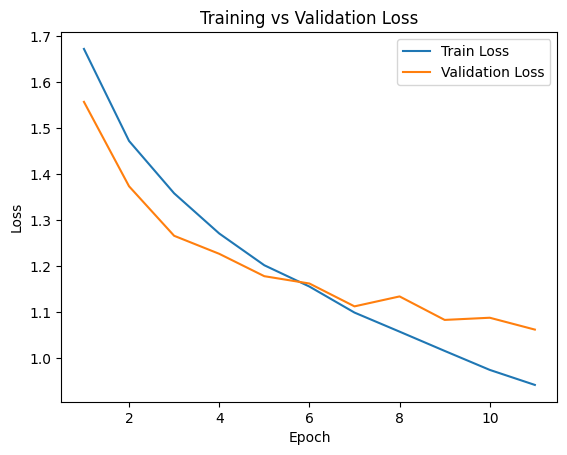

```python
import matplotlib.pyplot as plt

min_val_loss_epoch = val_losses.index(min(val_losses)) + 1

# Truncate the data up to the minimum validation loss epoch
epochs_truncated = range(1, min_val_loss_epoch + 1)
train_losses_truncated = train_losses[:min_val_loss_epoch]
val_losses_truncated = val_losses[:min_val_loss_epoch]

plt.figure()
plt.plot(epochs_truncated, train_losses_truncated, label="Train Loss")
plt.plot(epochs_truncated, val_losses_truncated, label="Validation Loss")
plt.xlabel("Epoch")
plt.ylabel("Loss")
plt.title("Training vs Validation Loss")
plt.legend()
plt.show()
```

## Testing

```python
model.load_state_dict(torch.load("best_model.pth"))
model.eval()

test_correct = 0
test_total = 0

with torch.no_grad():
    for x, y in test_loader:
        x, y = x.to(device), y.to(device)

        outputs = model(x)

        _, predicted = torch.max(outputs, 1)

        test_correct += (predicted == y).sum().item()
        test_total += y.size(0)

test_acc = test_correct / test_total
print(f"Test Accuracy: {test_acc:.4f}")
```

```
Test Accuracy: 0.7102
```

## Evaluation Metrics

Results are evaluated on many levels(emotion, datasets, gender, datasets+emotion, etc.) using classification reports, confusion matrices, and statistics. For detailed explanation, go to the “Results” section of the report(the “paper” pdf or html).

```python
from sklearn.metrics import classification_report, confusion_matrix
import seaborn as sns
import matplotlib.pyplot as plt
import numpy as np

# Predict on test set
all_preds = []
all_labels = []

model.eval()  # Evaluation mode

with torch.no_grad():
    for x, y in test_loader:
        x = x.to(device)
        outputs = model(x)

        _, predicted = torch.max(outputs, 1)

        all_preds.extend(predicted.cpu().numpy())
        all_labels.extend(y.numpy())

# Attach to dataframe
test_results = test_df.copy()
test_results["pred"] = all_preds
test_results["correct"] = test_results["pred"] == test_results["label"]
```

```python
print("\nAccuracy by Dataset Type:")
type_acc = test_results.groupby("type")["correct"].mean()

for t, acc in type_acc.items():
    print(f"{t}: {acc:.4f}")
```

```
Accuracy by Dataset Type:
Crema-D: 0.5779
EMOVO: 0.5000
EmoDB: 0.7826
Friends: 0.3333
RAVDESS: 0.6667
RAV_song: 0.9200
ShEMO: 0.7602
TESS: 1.0000
iPartment: 0.5657
```

```python
print("\nAccuracy by Gender:")
sex_acc = test_results.groupby("sex")["correct"].mean()

for s, acc in sex_acc.items():
    print(f"{s}: {acc:.4f}")
```

```
Accuracy by Gender:
female: 0.7386
male: 0.6819
```

```python
# Classification report
print("Angry:0 | Disgust:1 | Fear:2 | Happy:3 | Neutral:4 | Sad:5")
emotion_names = ["Angry", "Disgust", "Fear", "Happy", "Neutral", "Sad"]

print("\n===== Classification Report (All Test Data) =====")
print(classification_report(all_labels, all_preds, target_names=emotion_names))
```

```
Angry:0 | Disgust:1 | Fear:2 | Happy:3 | Neutral:4 | Sad:5

===== Classification Report (All Test Data) =====
              precision    recall  f1-score   support

       Angry       0.75      0.89      0.81       298
     Disgust       0.62      0.79      0.69       229
        Fear       0.63      0.73      0.67       238
       Happy       0.78      0.44      0.56       233
     Neutral       0.75      0.83      0.79       292
         Sad       0.82      0.50      0.63       242

    accuracy                           0.71      1532
   macro avg       0.72      0.70      0.69      1532
weighted avg       0.73      0.71      0.70      1532
```

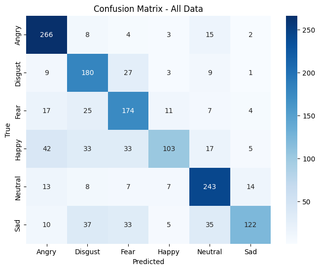

```python
# Confusion matrix for all datasets
cm = confusion_matrix(all_labels, all_preds)

plt.figure(figsize=(8, 6))
sns.heatmap(cm, annot=True, fmt="d", cmap="Blues", xticklabels=emotion_names, yticklabels=emotion_names)
plt.title("Confusion Matrix - All Data")
plt.xlabel("Predicted")
plt.ylabel("True")
plt.show()
```

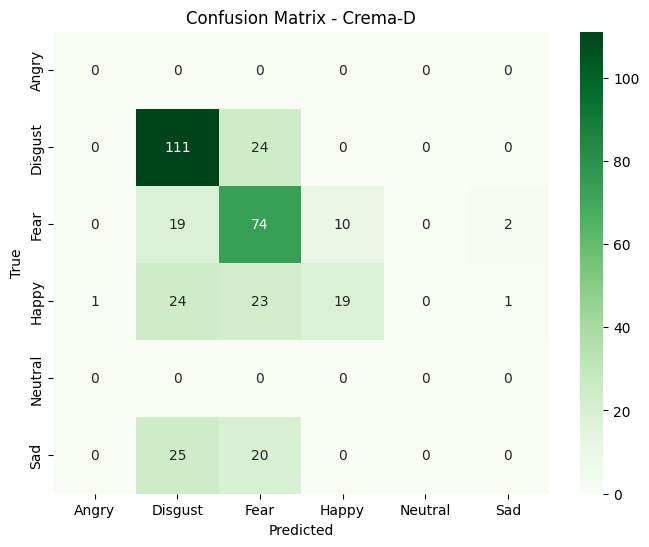

```
===== Crema-D Report =====
              precision    recall  f1-score   support

           0       0.00      0.00      0.00         0
           1       0.62      0.82      0.71       135
           2       0.52      0.70      0.60       105
           3       0.66      0.28      0.39        68
           5       0.00      0.00      0.00        45

    accuracy                           0.58       353
   macro avg       0.36      0.36      0.34       353
weighted avg       0.52      0.58      0.52       353
```

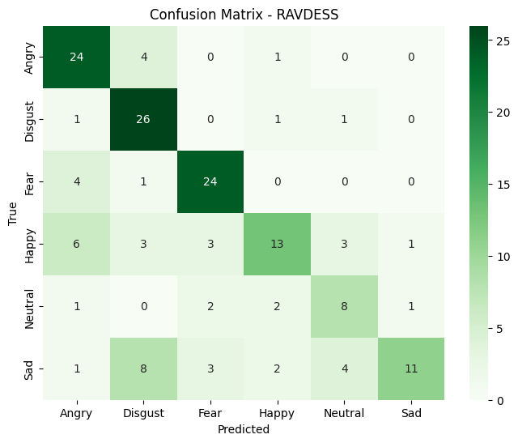

```
===== RAVDESS Report =====
              precision    recall  f1-score   support

           0       0.65      0.83      0.73        29
           1       0.62      0.90      0.73        29
           2       0.75      0.83      0.79        29
           3       0.68      0.45      0.54        29
           4       0.50      0.57      0.53        14
           5       0.85      0.38      0.52        29

    accuracy                           0.67       159
   macro avg       0.67      0.66      0.64       159
weighted avg       0.69      0.67      0.65       159
```

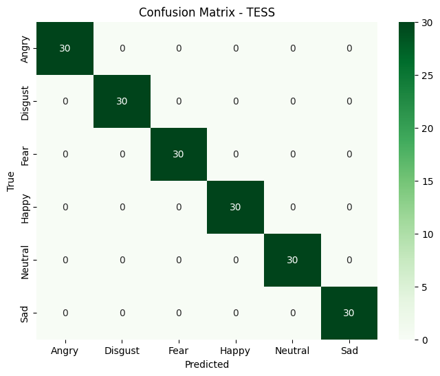

```
===== TESS Report =====
              precision    recall  f1-score   support

           0       1.00      1.00      1.00        30
           1       1.00      1.00      1.00        30
           2       1.00      1.00      1.00        30
           3       1.00      1.00      1.00        30
           4       1.00      1.00      1.00        30
           5       1.00      1.00      1.00        30

    accuracy                           1.00       180
   macro avg       1.00      1.00      1.00       180
weighted avg       1.00      1.00      1.00       180
```

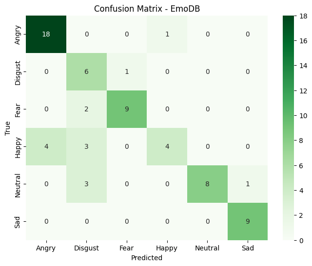

```
===== EmoDB Report =====
              precision    recall  f1-score   support

           0       0.82      0.95      0.88        19
           1       0.43      0.86      0.57         7
           2       0.90      0.82      0.86        11
           3       0.80      0.36      0.50        11
           4       1.00      0.67      0.80        12
           5       0.90      1.00      0.95         9

    accuracy                           0.78        69
   macro avg       0.81      0.78      0.76        69
weighted avg       0.83      0.78      0.78        69
```

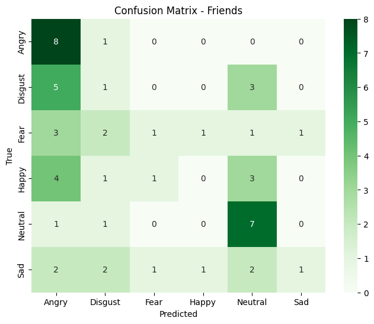

```
===== Friends Report =====
              precision    recall  f1-score   support

           0       0.35      0.89      0.50         9
           1       0.12      0.11      0.12         9
           2       0.33      0.11      0.17         9
           3       0.00      0.00      0.00         9
           4       0.44      0.78      0.56         9
           5       0.50      0.11      0.18         9

    accuracy                           0.33        54
   macro avg       0.29      0.33      0.25        54
weighted avg       0.29      0.33      0.25        54
```

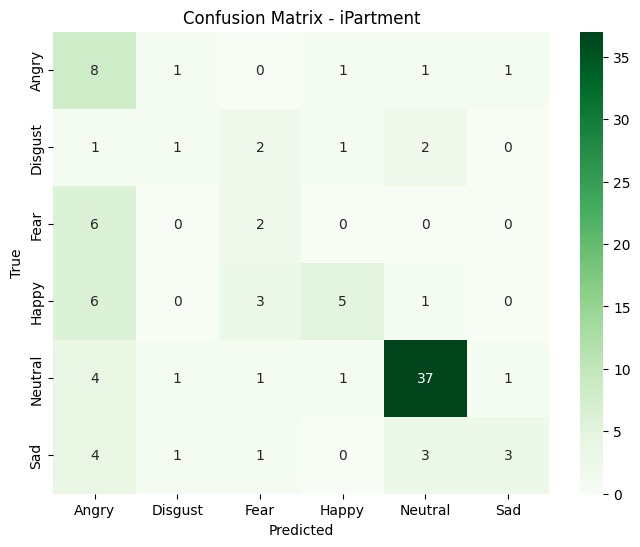

```
===== iPartment Report =====
              precision    recall  f1-score   support

           0       0.28      0.67      0.39        12
           1       0.25      0.14      0.18         7
           2       0.22      0.25      0.24         8
           3       0.62      0.33      0.43        15
           4       0.84      0.82      0.83        45
           5       0.60      0.25      0.35        12

    accuracy                           0.57        99
   macro avg       0.47      0.41      0.40        99
weighted avg       0.62      0.57      0.57        99
```

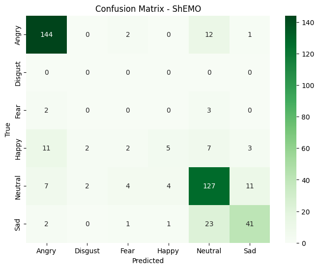

```
===== ShEMO Report =====
              precision    recall  f1-score   support

           0       0.87      0.91      0.89       159
           1       0.00      0.00      0.00         0
           2       0.00      0.00      0.00         5
           3       0.50      0.17      0.25        30
           4       0.74      0.82      0.78       155
           5       0.73      0.60      0.66        68

    accuracy                           0.76       417
   macro avg       0.47      0.42      0.43       417
weighted avg       0.76      0.76      0.75       417
```

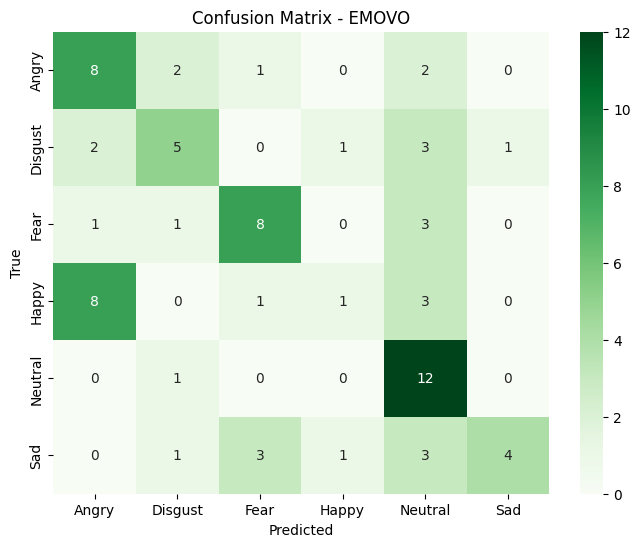

```
===== EMOVO Report =====
              precision    recall  f1-score   support

           0       0.42      0.62      0.50        13
           1       0.50      0.42      0.45        12
           2       0.62      0.62      0.62        13
           3       0.33      0.08      0.12        13
           4       0.46      0.92      0.62        13
           5       0.80      0.33      0.47        12

    accuracy                           0.50        76
   macro avg       0.52      0.50      0.46        76
weighted avg       0.52      0.50      0.46        76
```

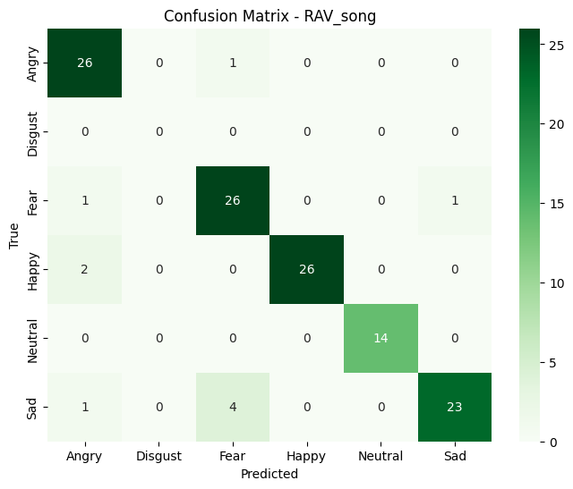

```
===== RAV_song Report =====
              precision    recall  f1-score   support

           0       0.87      0.96      0.91        27
           2       0.84      0.93      0.88        28
           3       1.00      0.93      0.96        28
           4       1.00      1.00      1.00        14
           5       0.96      0.82      0.88        28

    accuracy                           0.92       125
   macro avg       0.93      0.93      0.93       125
weighted avg       0.93      0.92      0.92       125
```

```python
# Confusion matrix for different dataset
for dataset_type in test_results["type"].unique():
    subset = test_results[test_results["type"] == dataset_type]

    y_true = subset["label"].values
    y_pred = subset["pred"].values

    cm = confusion_matrix(y_true, y_pred, labels= [0, 1, 2, 3, 4, 5])

    plt.figure(figsize=(8, 6))
    sns.heatmap(cm, annot=True, fmt="d", cmap="Greens",
                xticklabels=emotion_names,
                yticklabels=emotion_names)

    plt.title(f"Confusion Matrix - {dataset_type}")
    plt.xlabel("Predicted")
    plt.ylabel("True")
    plt.show()

    print(f"\n===== {dataset_type} Report =====")
    print(classification_report(y_true, y_pred))
```

```python
print("\nAccuracy by Type + Gender:")
type_sex_acc = test_results.groupby(["type", "sex"])["correct"].mean()

for (t, s), acc in type_sex_acc.items():
    print(f"{t} - {s}: {acc:.4f}")
```

```
Accuracy by Type + Gender:
Crema-D - female: 0.6204
Crema-D - male: 0.5509
EMOVO - female: 0.5143
EMOVO - male: 0.4878
EmoDB - female: 0.7812
EmoDB - male: 0.7838
Friends - female: 0.2903
Friends - male: 0.3913
RAVDESS - female: 0.6835
RAVDESS - male: 0.6500
RAV_song - female: 0.9038
RAV_song - male: 0.9315
ShEMO - female: 0.7048
ShEMO - male: 0.7968
TESS - female: 1.0000
iPartment - female: 0.5660
iPartment - male: 0.5652
```

```python
print("\nAccuracy by Type + Emotion:")
type_emo_acc = test_results.groupby(["type", "emotion"])["correct"].mean()

for (t, e), acc in type_emo_acc.items():
    print(f"{t} - {e}: {acc:.4f}")
```

```
Accuracy by Type + Emotion:
Crema-D - DIS: 0.8222
Crema-D - FEA: 0.7048
Crema-D - HAP: 0.2794
Crema-D - SAD: 0.0000
EMOVO - angry: 0.6154
EMOVO - disgust: 0.4167
EMOVO - fear: 0.6154
EMOVO - happy: 0.0769
EMOVO - neutral: 0.9231
EMOVO - sad: 0.3333
EmoDB - angry: 0.9474
EmoDB - disgust: 0.8571
EmoDB - fear: 0.8182
EmoDB - happy: 0.3636
EmoDB - neutral: 0.6667
EmoDB - sad: 1.0000
Friends - ANG: 0.8889
Friends - DIS: 0.1111
Friends - FEA: 0.1111
Friends - HAP: 0.0000
Friends - NEU: 0.7778
Friends - SAD: 0.1111
RAVDESS - angry: 0.8276
RAVDESS - disgust: 0.8966
RAVDESS - fear: 0.8276
RAVDESS - happy: 0.4483
RAVDESS - neutral: 0.5714
RAVDESS - sad: 0.3793
RAV_song - angry: 0.9630
RAV_song - fear: 0.9286
RAV_song - happy: 0.9286
RAV_song - neutral: 1.0000
RAV_song - sad: 0.8214
ShEMO - angry: 0.9057
ShEMO - fear: 0.0000
ShEMO - happy: 0.1667
ShEMO - neutral: 0.8194
ShEMO - sad: 0.6029
TESS - angry: 1.0000
TESS - disgust: 1.0000
TESS - fear: 1.0000
TESS - happy: 1.0000
TESS - neutral: 1.0000
TESS - sad: 1.0000
iPartment - ANG: 0.6667
iPartment - DIS: 0.1429
iPartment - FEA: 0.2500
iPartment - HAP: 0.3333
iPartment - NEU: 0.8222
iPartment - SAD: 0.2500
```